# Ford GoBike Data Investigation & Visualization

## Dataset Overview

The dataset, 201902-fordgobike-tripdata.csv, is downloaded from Udacity classroom and licensed by Ford GoBike. This dataset includes 183,411 trips with 16 features such as locations, time, and user attributes. There are start and end stations. I noticed that most trips happen on the same stations, so I subset the dataset by choosing top 5 trips start stations with the most trips.

# Univariate Analysis

# VISUALIZATION 1

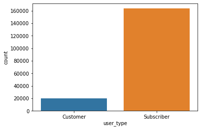

There are only two(2) types of users, Customer and Subscriber. And it also shows that there are more of Subscriber than Customer

# VISUALIZATION 2

### What gender has the highest riders?

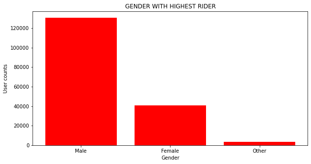

This shows the Male gender has the highest member count.

# VISUALIZATION 3

### How does the Datetime affect the ride?

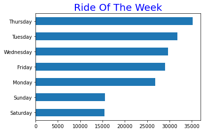

This show Thursday has the highest day ride count and saturday has the lowest day ride count, and it also show the lowest riders are on the weekends.

# Visualization 4

# Bivariate Exploration

#### Lets start with looking at the correlation between trip duration and age.

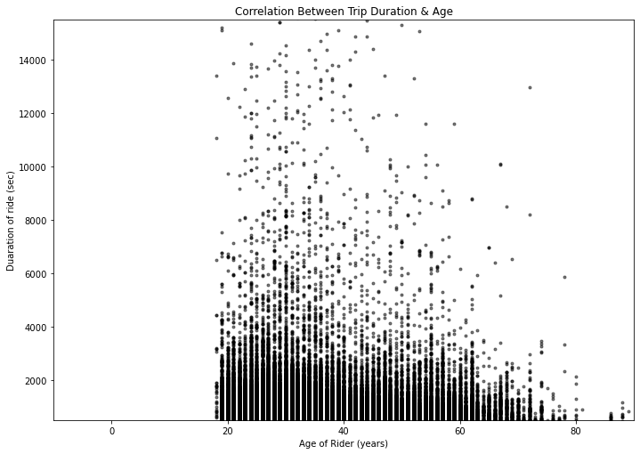

From these we can say that most frequent users of bikes are between 20 and 60 years of age, and most of the durations are under 6000 and age is under 80

# VISUALIZATION 5

## MULTIVARIATE EXPLORATION

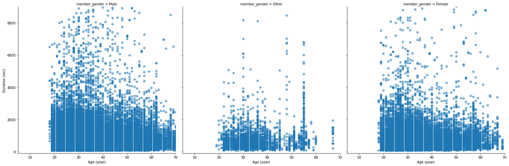

This shows rider of age 20 - 60 has more duration and We can see a jump in older age, close to 60 years of age